# Models for preliminary expense prediction

Christian Amaro INEGI

2025-04-21

In this section, the libraries required to perform the statistical analysis are loaded. These tools allow for data manipulation and cleaning, as well as the implementation, visualization, and validation of statistical models. A random seed (set.seed(123)) is also included to ensure reproducibility in processes that involve randomness, such as data partitioning or model training.

dplyr, tidyverse, readxl, readr, and foreign: These packages facilitate reading, transforming, and cleaning data from various sources such as Excel files, CSV files, or statistical formats like .sav.

caTools: This package is primarily used to split the dataset into training and testing subsets.

corrplot: Provides tools to visualize correlation matrices to assess relationships between numerical variables.

quantreg: Implements quantile regression models, which are useful for analyzing the effects of independent variables at different quantiles of the distribution.

rpart and rpart.plot: Allow for the creation and graphical representation of decision trees.

randomForest: Used to build random forest models for classification and regression tasks, offering robustness against overfitting.

factoextra: Facilitates the visualization and interpretation of results from multivariate analyses, such as Principal Component Analysis (PCA).

patchwork: Allows multiple plots generated with ggplot2 to be combined into a single visualization.

writexl: Enables the export of tables and analytical results directly into Excel files.

Importing the dataset: The file “BASE.xlsx” is read from the first sheet using the read_xlsx() function, keeping the column names as defined in the source file (col_names = TRUE).

Renaming key variable: The variable “NUEVA” is renamed to “Existencias” to improve interpretability and ensure semantic consistency in the subsequent analysis.

Preprocessing and cleaning: A list of all variable names in the dataframe is obtained using colnames(), which allows transformations to be applied automatically through a for loop.

Replacing missing values: Using a for loop, all variables in the dataset are scanned and missing values (NA) are replaced with zeros (0). This approach ensures that subsequent statistical analyses are optimized, functions and models work with complete data, and potential errors due to missing values are avoided.

```r
datos <- read_xlsx(path = "BASE.xlsx", sheet = 1,col_names = T)

datos <- datos %>% rename(Existencias = NUEVA)

# nombres de variables para ciclo for

variables <- colnames(datos)

# se quitan los NA y se convierten en 0

for (var in variables) {

 datos[[var]] <- ifelse(is.na(datos[[var]]), 0, datos[[var]])

}
```

Exploratory correlation analysis: At this stage, an exploratory analysis of linear relationships between the variables in the dataset is performed. A correlation matrix is generated using the cor() function applied to the entire dataframe, and it is then visualized using the corrplot() function.

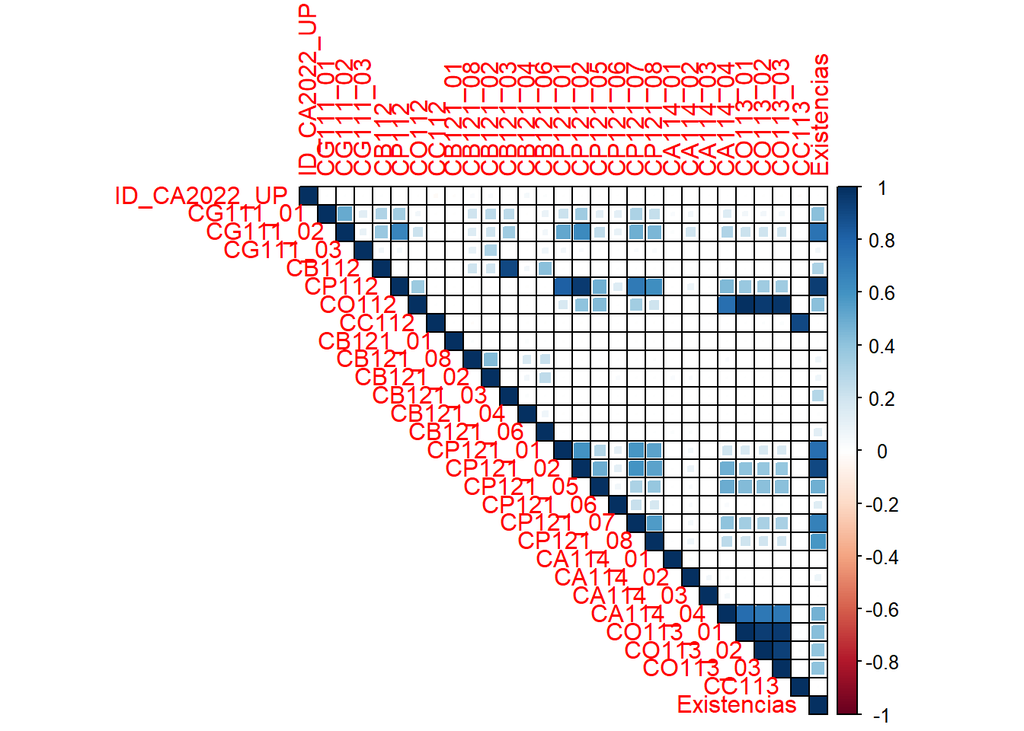

```r
corrplot(cor(datos), type = "upper", method = "square",addgrid.col = T)
```

```r
library(dplyr)

# Se normalizan variables

datos_norm <- datos %>%
  mutate(
    CB112 = log(CB112),
    CP112 = log(CP112),
    CO112 = log(CO112),
    CC112 = log(CC112),
    CB121_01 = log(CB121_01),
    CB121_08 = log(CB121_08),
    CB121_02 = log(CB121_02),
    CB121_03 = log(CB121_03),
    CB121_04 = log(CB121_04),
    CB121_06 = log(CB121_06),
    CP121_01 = log(CP121_01),
    CP121_02 = log(CP121_02),
    CP121_05 = log(CP121_05),
    CP121_06 = log(CP121_06),
    CP121_07 = log(CP121_07),
    CP121_08 = log(CP121_08),
    CA114_01 = log(CA114_01),
    CA114_02 = log(CA114_02),
    CA114_03 = log(CA114_03),
    CA114_04 = log(CA114_04),
    CO113_01 = log(CO113_01),
    CO113_02 = log(CO113_02),
    CO113_03 = log(CO113_03),
    CC113 = log(CC113),
    Existencias = log(Existencias)
  )

# Se quitan los infinitos

for (var in variables) {

 datos_norm[[var]] <- ifelse((is.infinite(datos_norm[[var]])), 0, datos_norm[[var]])

}
```

Multiple linear regression modeling: In this section, a multiple linear regression model is built with the aim of predicting the variable CG111_01, which represents food expenses. The analysis starts with the transformed dataset (datos_norm), selecting relevant variables and splitting the data into training and testing subsets.

The variables ID_CA2022_UP, CG111_02, and CG111_03 are removed as they are not considered predictors for this model. The target variable (CG111_01) is retained as the dependent variable in the analysis.

Next, the dataset is partitioned using the sample.split() function from the caTools package, randomly allocating 80% of the data for training and the remaining 20% for model validation.

Subsequently, a multiple linear regression model is fitted using all available variables as predictors.

$$\begin{align*}
\text{CG111_01}_i &= \beta_0 + \beta_1 \cdot \text{CB112}_i +
\beta_2 \cdot \text{CP112}_i + \beta_3 \cdot \text{CO112}_i + \beta_4
\cdot \text{CC112}_i \\
&\quad + \beta_5 \cdot \text{CB121_01}_i + \beta_6 \cdot
\text{CB121_08}_i + \beta_7 \cdot \text{CB121_02}_i + \beta_8 \cdot
\text{CB121_03}_i \\
&\quad + \beta_9 \cdot \text{CB121_04}_i + \beta_{10} \cdot
\text{CB121_06}_i + \beta_{11} \cdot \text{CP121_01}_i + \beta_{12}
\cdot \text{CP121_02}_i \\
&\quad + \beta_{13} \cdot \text{CP121_05}_i + \beta_{14} \cdot
\text{CP121_06}_i + \beta_{15} \cdot \text{CP121_07}_i + \beta_{16}
\cdot \text{CP121_08}_i \\
&\quad + \beta_{17} \cdot \text{CA114_01}_i + \beta_{18} \cdot
\text{CA114_02}_i + \beta_{19} \cdot \text{CA114_03}_i + \beta_{20}
\cdot \text{CA114_04}_i \\
&\quad + \beta_{21} \cdot \text{CO113_01}_i + \beta_{22} \cdot
\text{CO113_02}_i + \beta_{23} \cdot \text{CO113_03}_i + \beta_{24}
\cdot \text{CC113}_i \\
&\quad + \beta_{25} \cdot \text{Existencias}_i + \varepsilon_i
\end{align*}$$

Residual analysis and model evaluation: Once the model has been fitted, a graphical analysis of the residuals is performed to assess whether the classical assumptions of the linear model are satisfied, including normality, homoscedasticity, and linearity.

Finally, a statistical summary of the model is presented using summary(modelo1), which allows for the identification of the statistical significance of each independent variable, the adjusted coefficient of determination (adjusted R²) as a measure of model fit, and any potentially irrelevant or redundant variables.

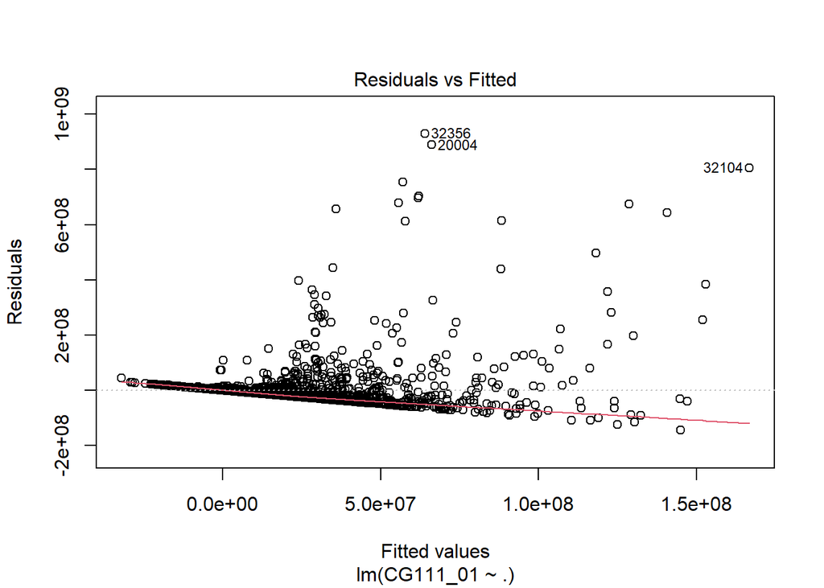

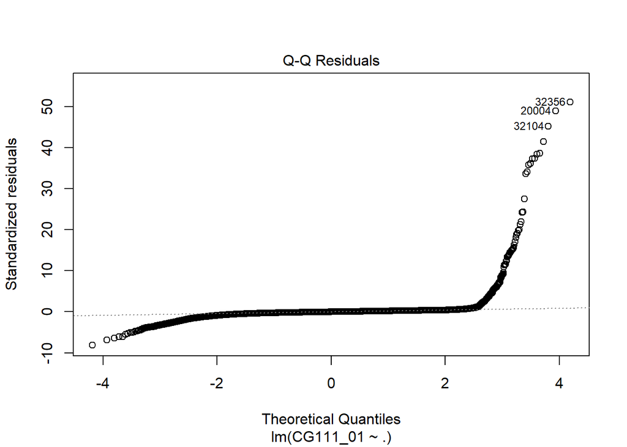

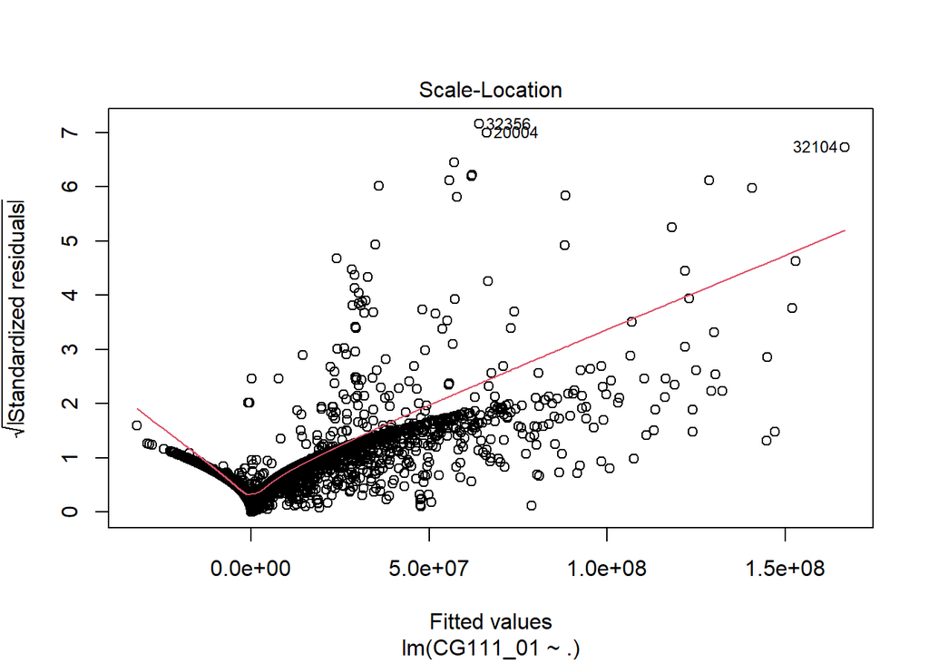

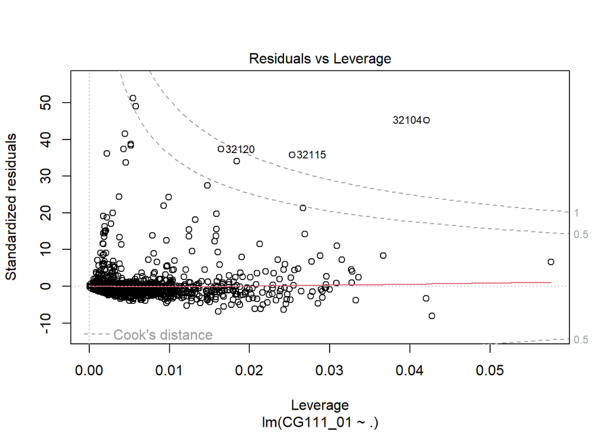

```r
CG111_01 <- datos_norm[,-c(1,3,4)]


split <- sample.split(Y = CG111_01$CG111_01, SplitRatio = .80)

training <- subset(CG111_01, split == T)
testing <- subset(CG111_01, split == F)

modelo1 <- lm(formula = CG111_01 ~ ., data = training)

plot(modelo1)
```

```r
summary(modelo1)
```

```
##
## Call:
## lm(formula = CG111_01 ~ ., data = training)
##
## Residuals:
##        Min         1Q     Median         3Q        Max
## -144949649   -2744487      45393    2586942  929046158
##
## Coefficients:
##              Estimate Std. Error t value Pr(>|t|)
## (Intercept) -22791311     480885 -47.395  < 2e-16 ***
## CB112         1256022     191072   6.574 4.98e-11 ***
## CP112        -3816690     261387 -14.602  < 2e-16 ***
## CO112        -1168760     393092  -2.973 0.002949 **
## CC112        -1026727     166176  -6.179 6.54e-10 ***
## CB121_01      -413472     430535  -0.960 0.336876
## CB121_08     -1460022     100915 -14.468  < 2e-16 ***
## CB121_02      -255151      75070  -3.399 0.000677 ***
## CB121_03      -181165     102889  -1.761 0.078284 .
## CB121_04     -4165704     154180 -27.019  < 2e-16 ***
## CB121_06      -845324     112791  -7.495 6.81e-14 ***
## CP121_01      1308789     246690   5.305 1.13e-07 ***
## CP121_02      3844533     238155  16.143  < 2e-16 ***
## CP121_05     -4413613     325481 -13.560  < 2e-16 ***
## CP121_06     11672731     573320  20.360  < 2e-16 ***
## CP121_07      2077289     303931   6.835 8.35e-12 ***
## CP121_08     -1836173     333849  -5.500 3.82e-08 ***
## CA114_01      -769711     154302  -4.988 6.12e-07 ***
## CA114_02       726343     125805   5.774 7.83e-09 ***
## CA114_03     -2542058     238426 -10.662  < 2e-16 ***
## CA114_04      1920474     106788  17.984  < 2e-16 ***
## CO113_01        55578     296136   0.188 0.851131
## CO113_02      1009455     438957   2.300 0.021473 *
## CO113_03      -385664     339008  -1.138 0.255284
## CC113         -403976     273409  -1.478 0.139536
## Existencias   6658678     174204  38.223  < 2e-16 ***
## ---
## Signif. codes:  0 '***' 0.001 '**' 0.01 '*' 0.05 '.' 0.1 ' ' 1
##
## Residual standard error: 18200000 on 35389 degrees of freedom
## Multiple R-squared:  0.1909, Adjusted R-squared:  0.1903
## F-statistic:   334 on 25 and 35389 DF,  p-value: < 2.2e-16
```

Model refinement using stepwise selection: After building the initial multiple linear regression model (modelo1), the statistical summary (summary(modelo1)) reveals that some variables do not contribute significantly to the model (high p-values). To improve model parsimony and performance, the Akaike Information Criterion (AIC) is used as an automatic variable selection method.

The stepAIC() function from the MASS package performs this selection efficiently, iteratively evaluating which variables should be included or excluded based on their contribution to the balance between model fit and complexity.

The argument direction = “both” is applied to allow both inclusion and exclusion of variables at each step of the algorithm (bidirectional method).

Finally, the statistical summary of the optimized model is reviewed again.

The purpose of this procedure is to reduce model complexity by removing redundant or uninformative predictors, improve interpretability by focusing on a more manageable subset of variables, and prevent overfitting by maintaining a balance between model accuracy and generalization.

This refined model serves as the basis for evaluating predictive performance on the test data and comparing it with future modeling approaches.

This is the final model:

```r
MASS::stepAIC(object = modelo1, direction = "both")
```

```
## Start:  AIC=1184075
## CG111_01 ~ CB112 + CP112 + CO112 + CC112 + CB121_01 + CB121_08 +
##     CB121_02 + CB121_03 + CB121_04 + CB121_06 + CP121_01 + CP121_02 +
##     CP121_05 + CP121_06 + CP121_07 + CP121_08 + CA114_01 + CA114_02 +
##     CA114_03 + CA114_04 + CO113_01 + CO113_02 + CO113_03 + CC113 +
##     Existencias
##
##               Df  Sum of Sq        RSS     AIC
## - CO113_01     1 1.1663e+13 1.1718e+19 1184073
## - CB121_01     1 3.0540e+14 1.1719e+19 1184074
## - CO113_03     1 4.2855e+14 1.1719e+19 1184074
## <none>                      1.1718e+19 1184075
## - CC113        1 7.2291e+14 1.1719e+19 1184075
## - CB121_03     1 1.0266e+15 1.1719e+19 1184076
## - CO113_02     1 1.7512e+15 1.1720e+19 1184078
## - CO112        1 2.9273e+15 1.1721e+19 1184081
## - CB121_02     1 3.8253e+15 1.1722e+19 1184084
## - CA114_01     1 8.2397e+15 1.1727e+19 1184097
## - CP121_01     1 9.3204e+15 1.1728e+19 1184101
## - CP121_08     1 1.0017e+16 1.1728e+19 1184103
## - CA114_02     1 1.1038e+16 1.1729e+19 1184106
## - CC112        1 1.2641e+16 1.1731e+19 1184111
## - CB112        1 1.4309e+16 1.1733e+19 1184116
## - CP121_07     1 1.5468e+16 1.1734e+19 1184119
## - CB121_06     1 1.8599e+16 1.1737e+19 1184129
## - CA114_03     1 3.7641e+16 1.1756e+19 1184186
## - CP121_05     1 6.0889e+16 1.1779e+19 1184256
## - CB121_08     1 6.9311e+16 1.1788e+19 1184281
## - CP112        1 7.0600e+16 1.1789e+19 1184285
## - CP121_02     1 8.6292e+16 1.1805e+19 1184332
## - CA114_04     1 1.0710e+17 1.1825e+19 1184395
## - CP121_06     1 1.3726e+17 1.1856e+19 1184485
## - CB121_04     1 2.4173e+17 1.1960e+19 1184796
## - Existencias  1 4.8379e+17 1.2202e+19 1185505
##
## Step:  AIC=1184073
## CG111_01 ~ CB112 + CP112 + CO112 + CC112 + CB121_01 + CB121_08 +
##     CB121_02 + CB121_03 + CB121_04 + CB121_06 + CP121_01 + CP121_02 +
##     CP121_05 + CP121_06 + CP121_07 + CP121_08 + CA114_01 + CA114_02 +
##     CA114_03 + CA114_04 + CO113_02 + CO113_03 + CC113 + Existencias
```

[output cut: 47 more lines]

```
## - CP121_08     1 1.0001e+16 1.1729e+19 1184100
## - CA114_02     1 1.1067e+16 1.1730e+19 1184103
## - CC112        1 1.2861e+16 1.1732e+19 1184108
## - CB112        1 1.4195e+16 1.1733e+19 1184112
## - CP121_07     1 1.5476e+16 1.1734e+19 1184116
## - CB121_06     1 1.8478e+16 1.1737e+19 1184125
## - CA114_03     1 3.7825e+16 1.1757e+19 1184184
## - CP121_05     1 6.0916e+16 1.1780e+19 1184253
## - CB121_08     1 6.9265e+16 1.1788e+19 1184278
## - CP112        1 7.0868e+16 1.1790e+19 1184283
## - CP121_02     1 8.6434e+16 1.1805e+19 1184330
## - CA114_04     1 1.0717e+17 1.1826e+19 1184392
## - CP121_06     1 1.3724e+17 1.1856e+19 1184482
## - CB121_04     1 2.4269e+17 1.1961e+19 1184795
## - Existencias  1 4.8610e+17 1.2205e+19 1185509
```

```
##
## Call:
## lm(formula = CG111_01 ~ CB112 + CP112 + CO112 + CC112 + CB121_08 +
##     CB121_02 + CB121_03 + CB121_04 + CB121_06 + CP121_01 + CP121_02 +
##     CP121_05 + CP121_06 + CP121_07 + CP121_08 + CA114_01 + CA114_02 +
##     CA114_03 + CA114_04 + CO113_02 + CO113_03 + CC113 + Existencias,
##     data = training)
##
## Coefficients:
## (Intercept)        CB112        CP112        CO112        CC112     CB121_08
##   -22799238      1249474     -3820999     -1111151     -1029738     -1459436
##    CB121_02     CB121_03     CB121_04     CB121_06     CP121_01     CP121_02
##     -254595      -178866     -4171075      -842223      1310332      3847222
##    CP121_05     CP121_06     CP121_07     CP121_08     CA114_01     CA114_02
##    -4414222     11671252      2077340     -1834654      -769451       727265
##    CA114_03     CA114_04     CO113_02     CO113_03        CC113  Existencias
##    -2544919      1921059      1031311      -423141      -403552      6661698
```

```r
modelo1fit <- lm(formula = CG111_01 ~ CB112 + CP112 + CB121_08 + CB121_02 +
    CB121_03 + CB121_04 + CP121_01 + CP121_05 + CP121_06 + CP121_07 +
    CA114_01 + CA114_02 + CA114_04 + CO113_01, data = training)


summary(modelo1fit)
```

```
##
## Call:
## lm(formula = CG111_01 ~ CB112 + CP112 + CB121_08 + CB121_02 +
##     CB121_03 + CB121_04 + CP121_01 + CP121_05 + CP121_06 + CP121_07 +
##     CA114_01 + CA114_02 + CA114_04 + CO113_01, data = training)
##
## Residuals:
##        Min         1Q     Median         3Q        Max
## -145173414   -2109828      87139    1739311  951985160
##
## Coefficients:
##              Estimate Std. Error t value Pr(>|t|)
## (Intercept) -11955322     393724 -30.365  < 2e-16 ***
## CB112         3982332     137217  29.022  < 2e-16 ***
## CP112         2977390     146068  20.384  < 2e-16 ***
## CB121_08     -1036819     102967 -10.069  < 2e-16 ***
## CB121_02        43930      77042   0.570  0.56854
## CB121_03       743551      90797   8.189 2.72e-16 ***
## CB121_04     -3016200     149591 -20.163  < 2e-16 ***
## CP121_01     -1017046     232575  -4.373 1.23e-05 ***
## CP121_05     -1660820     316524  -5.247 1.55e-07 ***
## CP121_06     13136161     577927  22.730  < 2e-16 ***
## CP121_07      2772799     298753   9.281  < 2e-16 ***
## CA114_01     -1456421     156547  -9.303  < 2e-16 ***
## CA114_02       412090     128581   3.205  0.00135 **
## CA114_04       834050      93057   8.963  < 2e-16 ***
## CO113_01       335585     127343   2.635  0.00841 **
## ---
## Signif. codes:  0 '***' 0.001 '**' 0.01 '*' 0.05 '.' 0.1 ' ' 1
##
## Residual standard error: 18780000 on 35400 degrees of freedom
## Multiple R-squared:  0.1381, Adjusted R-squared:  0.1377
## F-statistic:   405 on 14 and 35400 DF,  p-value: < 2.2e-16
```

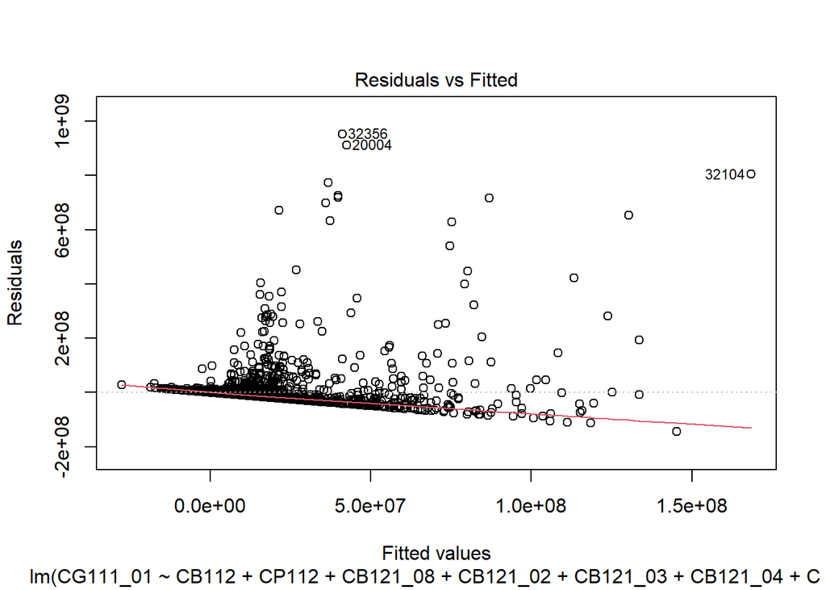

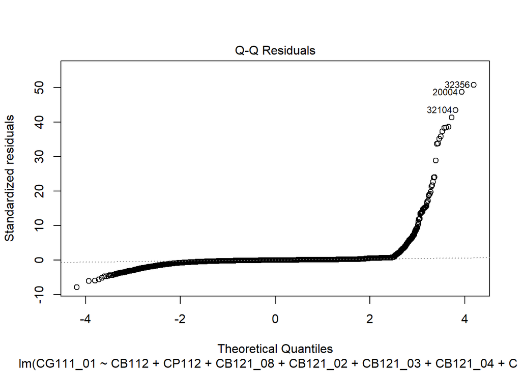

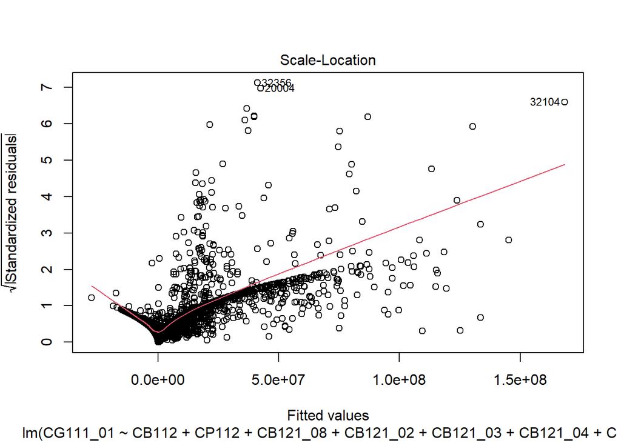

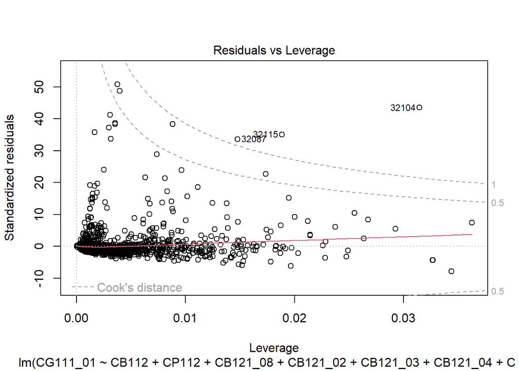

```r
plot(modelo1fit)
```

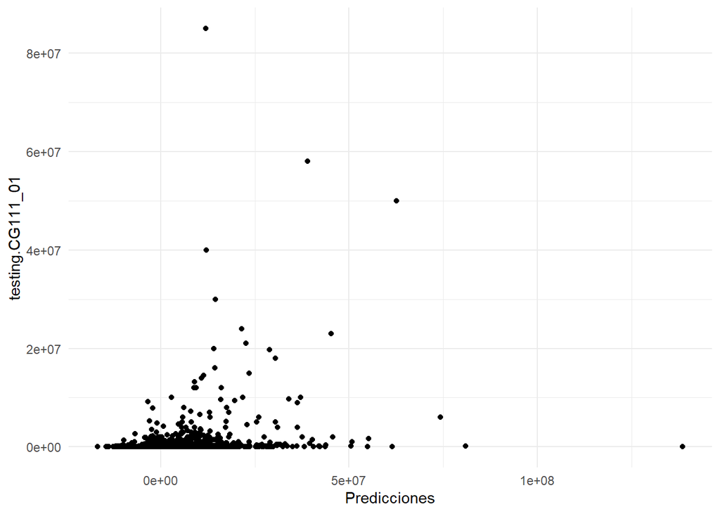

```r
testingok <- testing[,-1]

predicciones <- as.data.frame(predict.lm(object = modelo1fit, newdata = testingok ))

colnames(predicciones) <- "Predicciones"

comparacion <- data.frame(predicciones, testing$CG111_01)

ggplot(data = comparacion) + aes(x = Predicciones, y =testing.CG111_01) + geom_point() +theme_minimal()
```

Outlier detection and removal in the target variable: Since the model results did not achieve the expected performance, the potential bias caused by the presence of outliers in the target variable CG111_01 is addressed. Each observation is identified and classified as “Outlier” or “Non-Outlier” using the interquartile range (IQR) criterion, considering values below the first quartile minus 1.5 times the IQR or above the third quartile plus 1.5 times the IQR as outliers.

A frequency table is generated to quantify the number of observations in each category, and this information is visualized using a bar plot. Finally, the dataset is filtered to remove the outlier observations in order to clean the dataset and improve the quality of the model fit, and the column used for this classification is removed before continuing with the analysis.

```r
CG111_01w_atip <- CG111_01 %>%
  mutate(Atipico = ifelse(
    CG111_01 < quantile(CG111_01, 0.25, na.rm = TRUE) - 1.5 * IQR(CG111_01, na.rm = TRUE) |
    CG111_01 > quantile(CG111_01, 0.75, na.rm = TRUE) + 1.5 * IQR(CG111_01, na.rm = TRUE),
    "Atipico", "No atipico"
  ))



tabla <- data.frame(table(CG111_01w_atip$Atipico))



colnames(tabla) <- c("Estatus", "Frecuencia")


tabla$Estatus <- as.character(tabla$Estatus)



#tabla[3,] <- c("Total", sum(5549,38016))


#tabla_p <- data.frame(table(CG111_01w_atip$Atipico))

#colnames(tabla_p) <- c("Estatus", "Porcentaje")

#tabla_p$Porcentaje <- tabla_p$Porcentaje / 43565 * 100

knitr::kable(tabla)
```

| Estatus | Frecuencia |
| --- | --- |
| Atipico | 5549 |
| No atipico | 38016 |

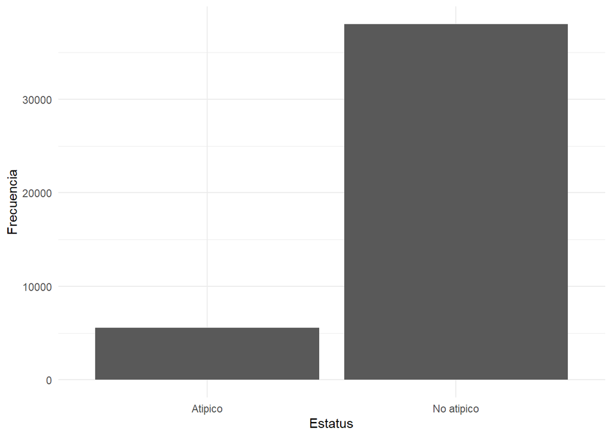

```r
#knitr::kable(tabla_p)

ggplot(data = tabla, aes(x = Estatus, y = Frecuencia)) + geom_bar(stat = "summary", fun = "sum") + theme_minimal()
```

```r
CG111_01w_atip <- CG111_01w_atip %>% filter(Atipico == "No atipico")

CG111_01w_atip <- CG111_01w_atip[,-27]
```

Correlation plot without outliers: A correlation plot is generated using the dataset with outliers removed. This visualization allows the assessment of linear relationships between variables in a cleaner dataset, minimizing the influence of extreme values on correlation coefficients.

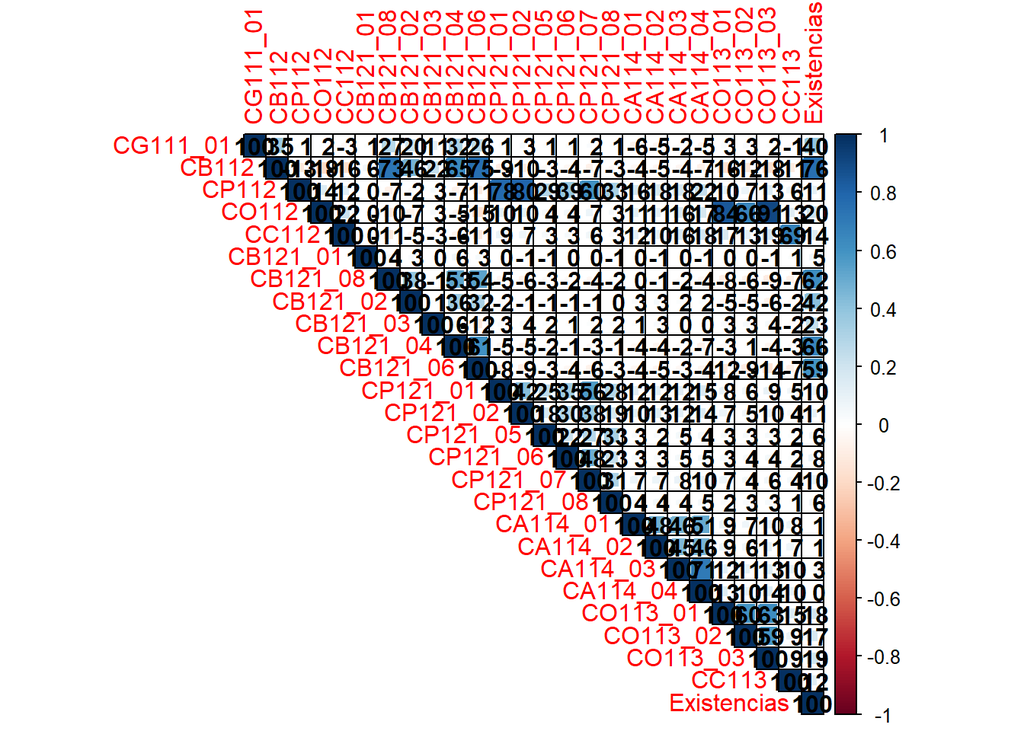

```r
corrplot(cor(CG111_01w_atip), type = "upper", method = "square", addgrid.col = T, addCoefasPercent = T, addCoef.col = T)
```

Modeling after outlier removal: After removing outliers, the clean dataset is again split into training (80%) and testing (20%) subsets using the sample.split function. A new multiple linear regression model (modelo1_watip) is fitted on the training data without outliers. Graphical residual analyses and a statistical summary are performed to evaluate the initial model fit.

Subsequently, a backward stepwise selection method based on the Akaike Information Criterion (stepAIC with direction = “backward”) is applied to optimize the model, resulting in a final fitted model (modelo1_watip_fit) that includes only the most relevant variables. This optimized model is also evaluated using a summary and diagnostic plots.

Finally, predictions are generated on the test set without outliers, and a dataframe is created that combines the predicted values with the actual observed values for subsequent comparison and evaluation.

The final model obtained is:

$$\begin{align*}
CG111_01_i &= \beta_0 + \beta_1 \cdot CB112_i + \beta_2 \cdot
CP112_i + \beta_3 \cdot CC112_i + \beta_4 \cdot CB121_08_i \\
&\quad + \beta_5 \cdot CB121_03_i + \beta_6 \cdot CB121_04_i +
\beta_7 \cdot CP121_01_i + \beta_8 \cdot CP121_02_i \\
&\quad + \beta_9 \cdot CP121_06_i + \beta_{10} \cdot CP121_07_i +
\beta_{11} \cdot CO113_01_i + \varepsilon_i
\end{align*}$$

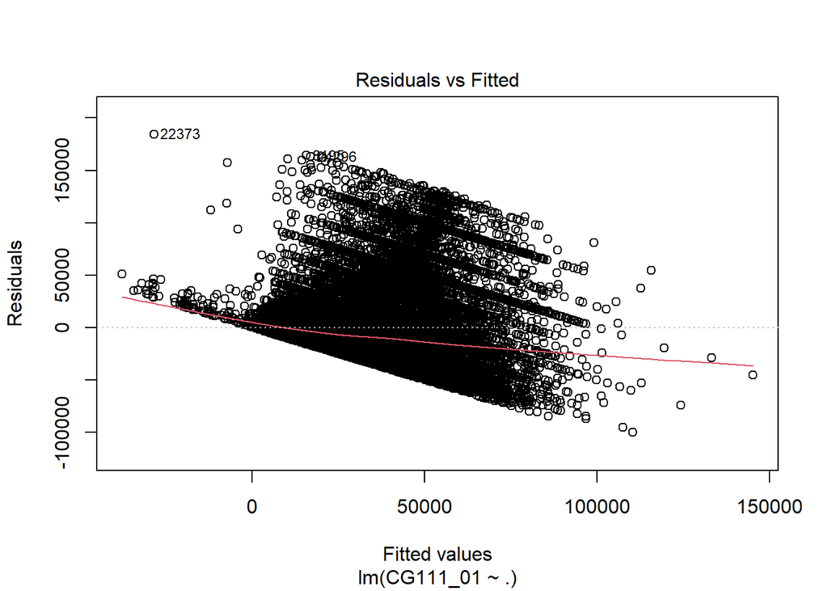

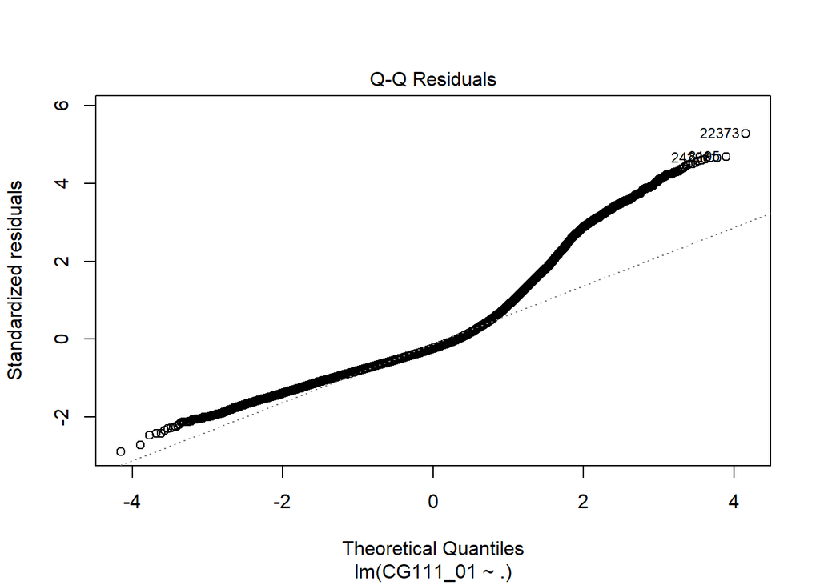

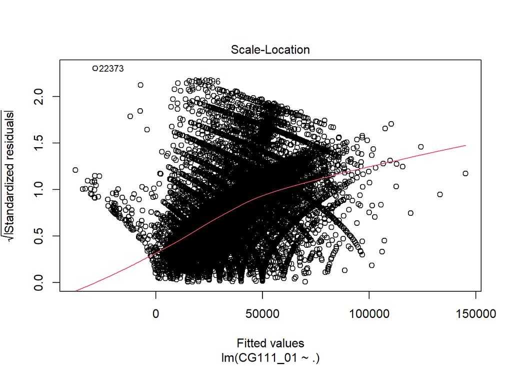

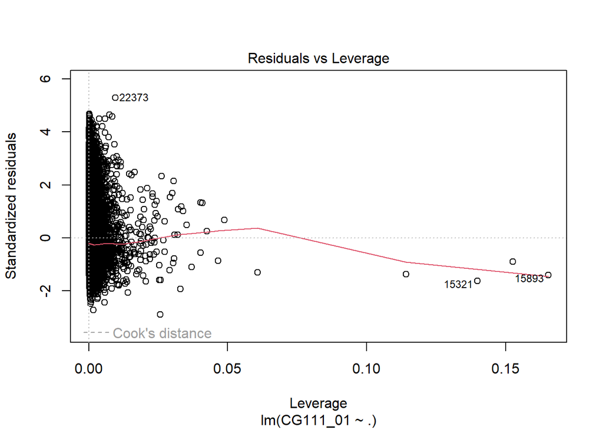

```r
split <- sample.split(Y = CG111_01w_atip$CG111_01, SplitRatio = .80)

training <- subset(CG111_01w_atip, split == T)
testing <- subset(CG111_01w_atip, split == F)




modelo1_watip <- lm(formula = CG111_01 ~ ., data = training)

plot(modelo1_watip)
```

```r
summary(modelo1_watip)
```

```
##
## Call:
## lm(formula = CG111_01 ~ ., data = training)
##
## Residuals:
##     Min      1Q  Median      3Q     Max
## -100304  -22294   -8521   13029  184290
##
## Coefficients:
##              Estimate Std. Error t value Pr(>|t|)
## (Intercept) -28745.22    1245.78 -23.074  < 2e-16 ***
## CB112         2945.26     476.67   6.179 6.54e-10 ***
## CP112        -2090.55     833.44  -2.508 0.012135 *
## CO112          142.14     845.12   0.168 0.866435
## CC112        -2150.31     343.06  -6.268 3.71e-10 ***
## CB121_01     -1848.84     885.02  -2.089 0.036712 *
## CB121_08      -603.14     239.22  -2.521 0.011696 *
## CB121_02       656.44     167.57   3.917 8.97e-05 ***
## CB121_03        28.41     244.50   0.116 0.907498
## CB121_04      3826.75     379.31  10.089  < 2e-16 ***
## CB121_06     -1545.57     267.01  -5.788 7.18e-09 ***
## CP121_01      1411.84     782.96   1.803 0.071365 .
## CP121_02      2775.79     775.37   3.580 0.000344 ***
## CP121_05     -1002.91    1555.65  -0.645 0.519133
## CP121_06     -5074.04    1929.99  -2.629 0.008567 **
## CP121_07      1193.45     973.32   1.226 0.220146
## CP121_08       519.92    1409.23   0.369 0.712178
## CA114_01     -2656.76     332.54  -7.989 1.40e-15 ***
## CA114_02      -728.39     307.29  -2.370 0.017776 *
## CA114_03      2165.38     529.24   4.091 4.30e-05 ***
## CA114_04      -495.12     257.66  -1.922 0.054661 .
## CO113_01       398.60     626.70   0.636 0.524762
## CO113_02      -570.39     945.13  -0.603 0.546182
## CO113_03     -1411.56     729.14  -1.936 0.052885 .
## CC113         -570.79     556.56  -1.026 0.305103
## Existencias  13993.70     506.87  27.608  < 2e-16 ***
## ---
## Signif. codes:  0 '***' 0.001 '**' 0.01 '*' 0.05 '.' 0.1 ' ' 1
##
## Residual standard error: 34990 on 30671 degrees of freedom
## Multiple R-squared:  0.182,  Adjusted R-squared:  0.1813
## F-statistic: 272.9 on 25 and 30671 DF,  p-value: < 2.2e-16
```

```r
MASS::stepAIC(object = modelo1_watip, direction = "backward")
```

```
## Start:  AIC=642382.8
## CG111_01 ~ CB112 + CP112 + CO112 + CC112 + CB121_01 + CB121_08 +
##     CB121_02 + CB121_03 + CB121_04 + CB121_06 + CP121_01 + CP121_02 +
##     CP121_05 + CP121_06 + CP121_07 + CP121_08 + CA114_01 + CA114_02 +
##     CA114_03 + CA114_04 + CO113_01 + CO113_02 + CO113_03 + CC113 +
##     Existencias
##
##               Df  Sum of Sq        RSS    AIC
## - CB121_03     1 1.6531e+07 3.7554e+13 642381
## - CO112        1 3.4636e+07 3.7554e+13 642381
## - CP121_08     1 1.6666e+08 3.7554e+13 642381
## - CO113_02     1 4.4594e+08 3.7554e+13 642381
## - CO113_01     1 4.9531e+08 3.7554e+13 642381
## - CP121_05     1 5.0889e+08 3.7554e+13 642381
## - CC113        1 1.2878e+09 3.7555e+13 642382
## - CP121_07     1 1.8409e+09 3.7555e+13 642382
## <none>                      3.7554e+13 642383
## - CP121_01     1 3.9812e+09 3.7558e+13 642384
## - CA114_04     1 4.5213e+09 3.7558e+13 642384
## - CO113_03     1 4.5888e+09 3.7558e+13 642384
## - CB121_01     1 5.3434e+09 3.7559e+13 642385
## - CA114_02     1 6.8795e+09 3.7560e+13 642386
## - CP112        1 7.7037e+09 3.7561e+13 642387
## - CB121_08     1 7.7837e+09 3.7561e+13 642387
## - CP121_06     1 8.4630e+09 3.7562e+13 642388
## - CP121_02     1 1.5692e+10 3.7569e+13 642394
## - CB121_02     1 1.8789e+10 3.7572e+13 642396
## - CA114_03     1 2.0497e+10 3.7574e+13 642397
## - CB121_06     1 4.1023e+10 3.7595e+13 642414
## - CB112        1 4.6744e+10 3.7600e+13 642419
## - CC112        1 4.8104e+10 3.7602e+13 642420
## - CA114_01     1 7.8152e+10 3.7632e+13 642445
## - CB121_04     1 1.2462e+11 3.7678e+13 642482
## - Existencias  1 9.3324e+11 3.8487e+13 643134
##
## Step:  AIC=642380.8
## CG111_01 ~ CB112 + CP112 + CO112 + CC112 + CB121_01 + CB121_08 +
##     CB121_02 + CB121_04 + CB121_06 + CP121_01 + CP121_02 + CP121_05 +
##     CP121_06 + CP121_07 + CP121_08 + CA114_01 + CA114_02 + CA114_03 +
##     CA114_04 + CO113_01 + CO113_02 + CO113_03 + CC113 + Existencias
```

[output cut: 213 more lines]

```
## - CB121_01     1 5.3662e+09 3.7565e+13 642374
## - CP112        1 6.5216e+09 3.7566e+13 642375
## - CA114_02     1 6.8454e+09 3.7566e+13 642375
## - CP121_06     1 7.2300e+09 3.7567e+13 642375
## - CB121_08     1 8.9963e+09 3.7568e+13 642377
## - CP121_02     1 1.4583e+10 3.7574e+13 642381
## - CB121_02     1 1.9150e+10 3.7578e+13 642385
## - CO113_03     1 2.0191e+10 3.7580e+13 642386
## - CA114_03     1 2.0218e+10 3.7580e+13 642386
## - CB121_06     1 5.4535e+10 3.7614e+13 642414
## - CB112        1 5.6324e+10 3.7616e+13 642415
## - CA114_01     1 7.8462e+10 3.7638e+13 642433
## - CC112        1 9.9490e+10 3.7659e+13 642451
## - CB121_04     1 1.2319e+11 3.7683e+13 642470
## - Existencias  1 1.0791e+12 3.8638e+13 643239
```

```
##
## Call:
## lm(formula = CG111_01 ~ CB112 + CP112 + CC112 + CB121_01 + CB121_08 +
##     CB121_02 + CB121_04 + CB121_06 + CP121_01 + CP121_02 + CP121_06 +
##     CA114_01 + CA114_02 + CA114_03 + CA114_04 + CO113_03 + Existencias,
##     data = training)
##
## Coefficients:
## (Intercept)        CB112        CP112        CC112     CB121_01     CB121_08
##    -28881.2       2889.8      -1819.3      -2394.5      -1851.3       -610.4
##    CB121_02     CB121_04     CB121_06     CP121_01     CP121_02     CP121_06
##       653.4       3794.7      -1555.1       1467.1       2623.8      -4371.1
##    CA114_01     CA114_02     CA114_03     CA114_04     CO113_03  Existencias
##     -2659.6       -725.7       2146.6       -477.7      -1167.6      14108.3
```

```r
modelo1_watip_fit <- lm(formula = CG111_01 ~ CB112 + CP112  + CC112 + CB121_08 +
    CB121_03 + CB121_04 + CP121_01 + CP121_02  + CP121_06 +
    CP121_07 + CO113_01 , data = training)



summary(modelo1_watip_fit)
```

```
##
## Call:
## lm(formula = CG111_01 ~ CB112 + CP112 + CC112 + CB121_08 + CB121_03 +
##     CB121_04 + CP121_01 + CP121_02 + CP121_06 + CP121_07 + CO113_01,
##     data = training)
##
## Residuals:
##    Min     1Q Median     3Q    Max
## -91579 -22708 -10175  13390 174560
##
## Coefficients:
##             Estimate Std. Error t value Pr(>|t|)
## (Intercept)  -5988.0      894.5  -6.694 2.20e-11 ***
## CB112         8640.6      317.6  27.207  < 2e-16 ***
## CP112        -3583.3      818.4  -4.378 1.20e-05 ***
## CC112          623.1      242.7   2.567 0.010261 *
## CB121_08       664.6      234.6   2.833 0.004616 **
## CB121_03      1570.0      212.2   7.399 1.41e-13 ***
## CB121_04      7488.0      352.1  21.267  < 2e-16 ***
## CP121_01      3249.6      791.3   4.107 4.02e-05 ***
## CP121_02      6282.3      770.9   8.149 3.80e-16 ***
## CP121_06     -2276.1     1946.1  -1.170 0.242178
## CP121_07      3766.9      980.1   3.843 0.000122 ***
## CO113_01      3567.3      275.6  12.943  < 2e-16 ***
## ---
## Signif. codes:  0 '***' 0.001 '**' 0.01 '*' 0.05 '.' 0.1 ' ' 1
##
## Residual standard error: 35560 on 30685 degrees of freedom
## Multiple R-squared:  0.1549, Adjusted R-squared:  0.1546
## F-statistic: 511.3 on 11 and 30685 DF,  p-value: < 2.2e-16
```

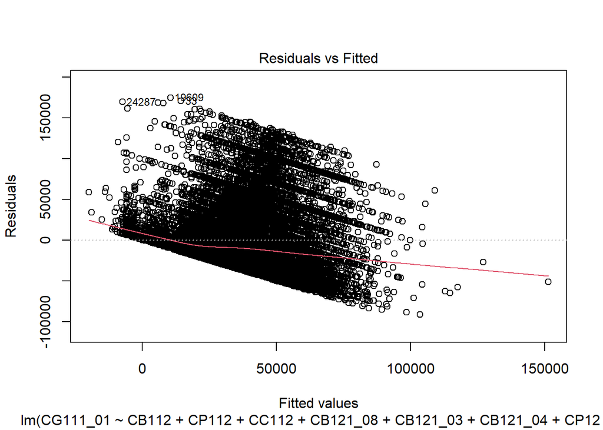

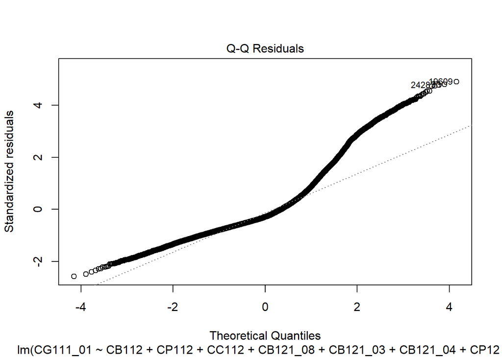

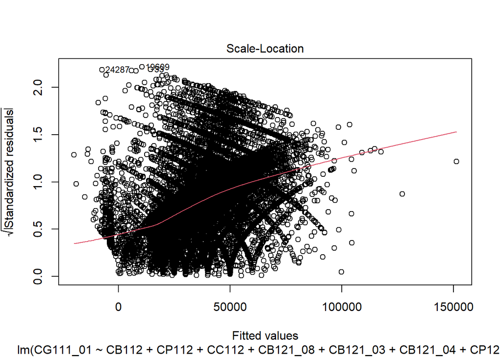

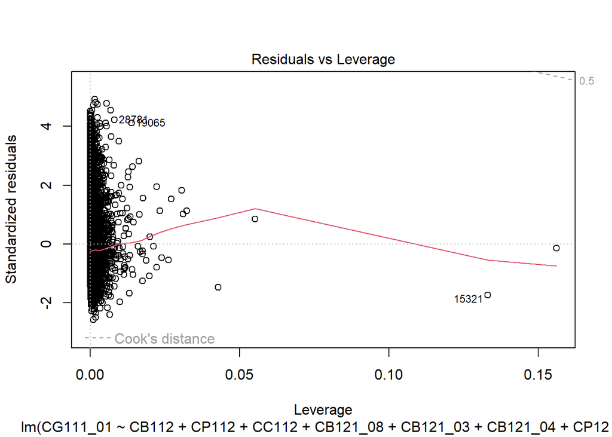

```r
plot(modelo1_watip_fit)
```

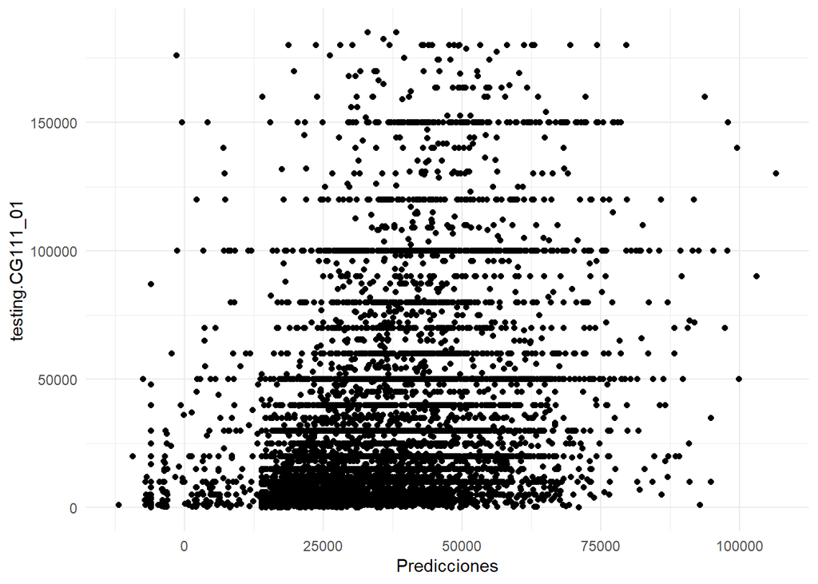

```r
testingok <- testing[,-1]

predicciones_watip <- as.data.frame(predict.lm(object = modelo1_watip_fit, newdata = testingok ))

colnames(predicciones_watip) <- "Predicciones"

comparacion <- data.frame(predicciones_watip, testing$CG111_01)

ggplot(data = comparacion) + aes(x = Predicciones, y =testing.CG111_01) + geom_point() +theme_minimal()
```

For the species-specific analysis, the variables CB112, CB121_01, CB121_08, CB121_02, CB121_03, CB121_04, and CB121_06 are selected as the main predictors. These variables were chosen due to their relevance in the bovine livestock context and their potential impact on food expenses. The selection aims to focus the model on key factors that describe specific characteristics of each species, enabling a more precise and tailored analysis for each group.

```r
CG111_01_cb <- datos_norm %>% select(CG111_01,CB112, CB121_01,CB121_08, CB121_02,CB121_03, CB121_04,CB121_06 )
```

Correlation plot

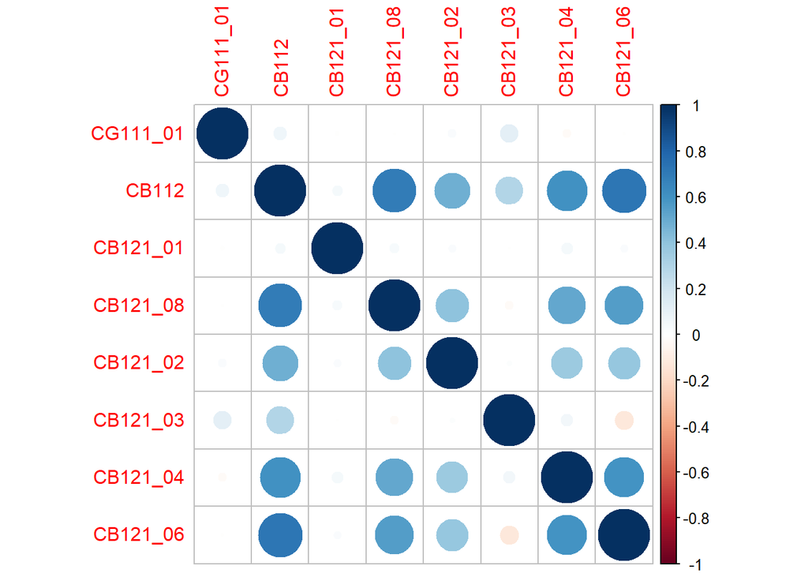

```r
corrplot(cor(CG111_01_cb))
```

Modeling for the bovine species: The data splitting process is repeated for the subset corresponding to the bovine species (CG111_01_cb), with 80% allocated for training and 20% for testing. A multiple linear regression model is fitted using all available variables, followed by optimization with stepAIC to select the most relevant predictors.

The summary and diagnostic plots of the final model are reviewed, and predictions are generated on the test set to compare with the actual observed values. This procedure is similar to the one performed previously but is applied specifically to the bovine species.

```r
split <- sample.split(Y = CG111_01_cb$CG111_01, SplitRatio = .80)

training <- subset(x = CG111_01_cb, split == T)
testing <- subset(x = CG111_01_cb, split == F)

testingok <- testing[,-1]

modelo_CB <- lm(formula = CG111_01 ~., data = training)

summary(modelo_CB)
```

```
##
## Call:
## lm(formula = CG111_01 ~ ., data = training)
##
## Residuals:
##       Min        1Q    Median        3Q       Max
## -36970545  -1824371   -742246    173855 959045312
##
## Coefficients:
##             Estimate Std. Error t value Pr(>|t|)
## (Intercept) -3990363     384027 -10.391  < 2e-16 ***
## CB112        2254188     178308  12.642  < 2e-16 ***
## CB121_01     -771041     468829  -1.645 0.100059
## CB121_08     -746629     109538  -6.816  9.5e-12 ***
## CB121_02      292580      81338   3.597 0.000322 ***
## CB121_03     1355103     109777  12.344  < 2e-16 ***
## CB121_04    -1944165     162162 -11.989  < 2e-16 ***
## CB121_06     -443763     122928  -3.610 0.000307 ***
## ---
## Signif. codes:  0 '***' 0.001 '**' 0.01 '*' 0.05 '.' 0.1 ' ' 1
##
## Residual standard error: 19970000 on 35407 degrees of freedom
## Multiple R-squared:  0.02528,    Adjusted R-squared:  0.02509
## F-statistic: 131.2 on 7 and 35407 DF,  p-value: < 2.2e-16
```

```r
MASS::stepAIC(object = modelo_CB, direction = "both")
```

```
## Start:  AIC=1190635
## CG111_01 ~ CB112 + CB121_01 + CB121_08 + CB121_02 + CB121_03 +
##     CB121_04 + CB121_06
##
##            Df  Sum of Sq        RSS     AIC
## <none>                   1.4117e+19 1190635
## - CB121_01  1 1.0784e+15 1.4118e+19 1190635
## - CB121_02  1 5.1590e+15 1.4123e+19 1190646
## - CB121_06  1 5.1960e+15 1.4123e+19 1190646
## - CB121_08  1 1.8525e+16 1.4136e+19 1190679
## - CB121_04  1 5.7311e+16 1.4175e+19 1190776
## - CB121_03  1 6.0756e+16 1.4178e+19 1190785
## - CB112     1 6.3724e+16 1.4181e+19 1190792
```

```
##
## Call:
## lm(formula = CG111_01 ~ CB112 + CB121_01 + CB121_08 + CB121_02 +
##     CB121_03 + CB121_04 + CB121_06, data = training)
##
## Coefficients:
## (Intercept)        CB112     CB121_01     CB121_08     CB121_02     CB121_03
##    -3990363      2254188      -771041      -746629       292580      1355103
##    CB121_04     CB121_06
##    -1944165      -443763
```

```r
summary(modelo_CB)
```

```
##
## Call:
## lm(formula = CG111_01 ~ ., data = training)
##
## Residuals:
##       Min        1Q    Median        3Q       Max
## -36970545  -1824371   -742246    173855 959045312
##
## Coefficients:
##             Estimate Std. Error t value Pr(>|t|)
## (Intercept) -3990363     384027 -10.391  < 2e-16 ***
## CB112        2254188     178308  12.642  < 2e-16 ***
## CB121_01     -771041     468829  -1.645 0.100059
## CB121_08     -746629     109538  -6.816  9.5e-12 ***
## CB121_02      292580      81338   3.597 0.000322 ***
## CB121_03     1355103     109777  12.344  < 2e-16 ***
## CB121_04    -1944165     162162 -11.989  < 2e-16 ***
## CB121_06     -443763     122928  -3.610 0.000307 ***
## ---
## Signif. codes:  0 '***' 0.001 '**' 0.01 '*' 0.05 '.' 0.1 ' ' 1
##
## Residual standard error: 19970000 on 35407 degrees of freedom
## Multiple R-squared:  0.02528,    Adjusted R-squared:  0.02509
## F-statistic: 131.2 on 7 and 35407 DF,  p-value: < 2.2e-16
```

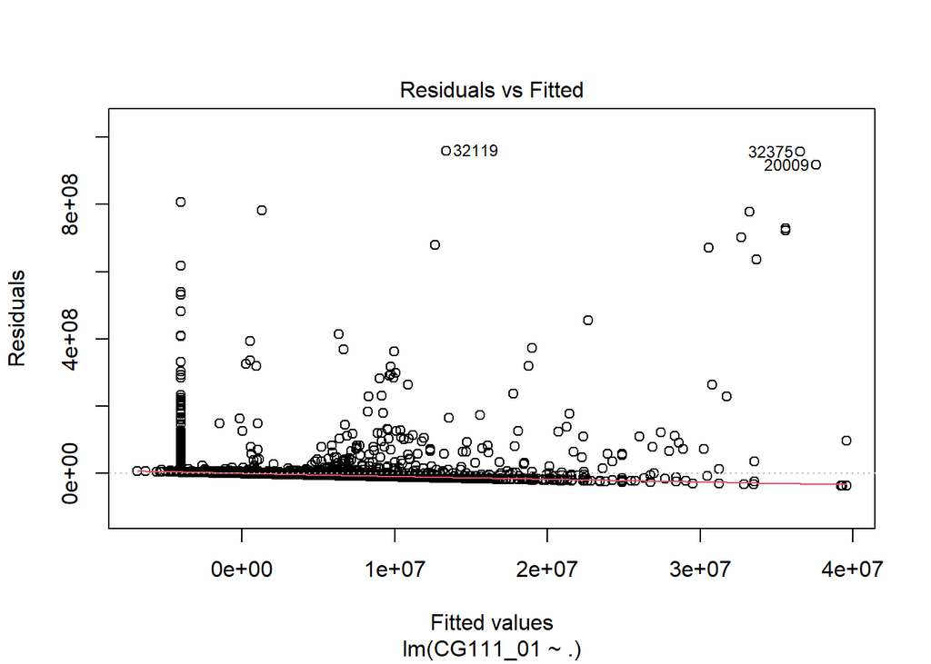

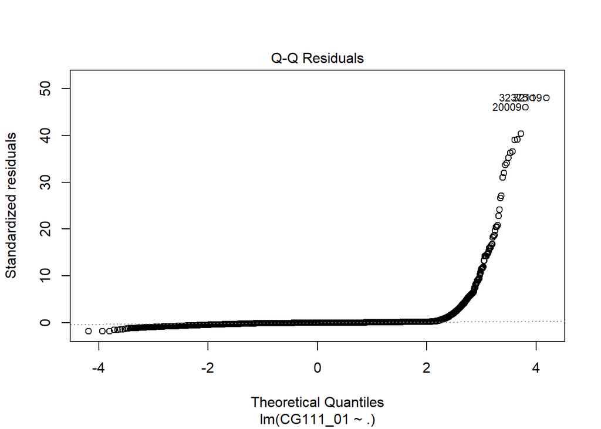

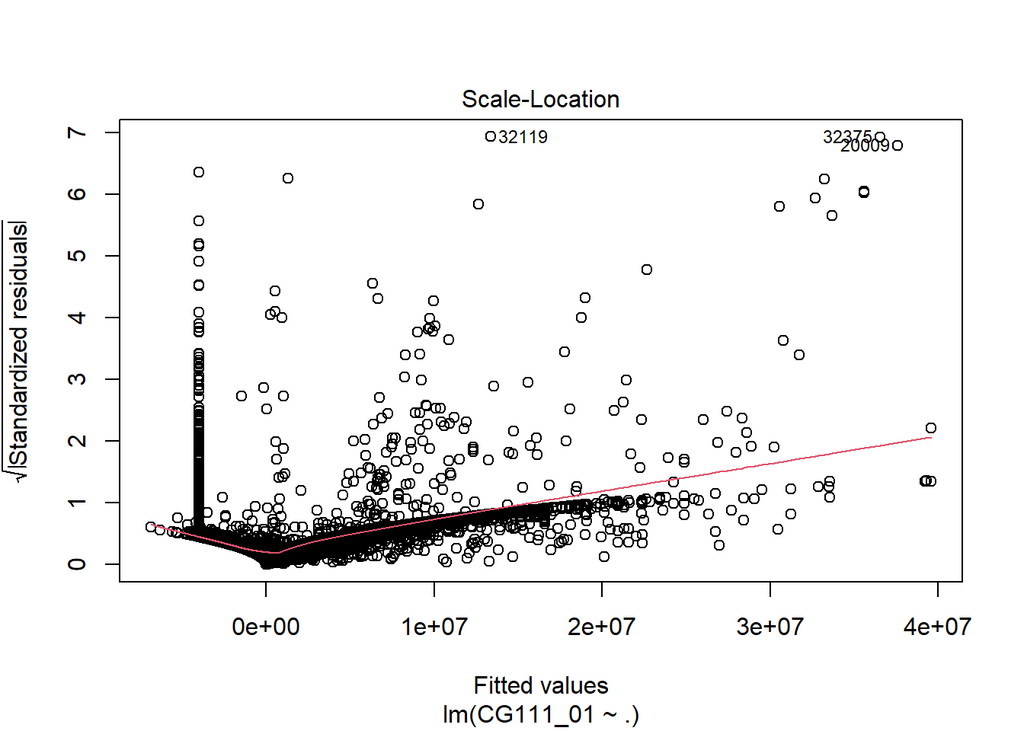

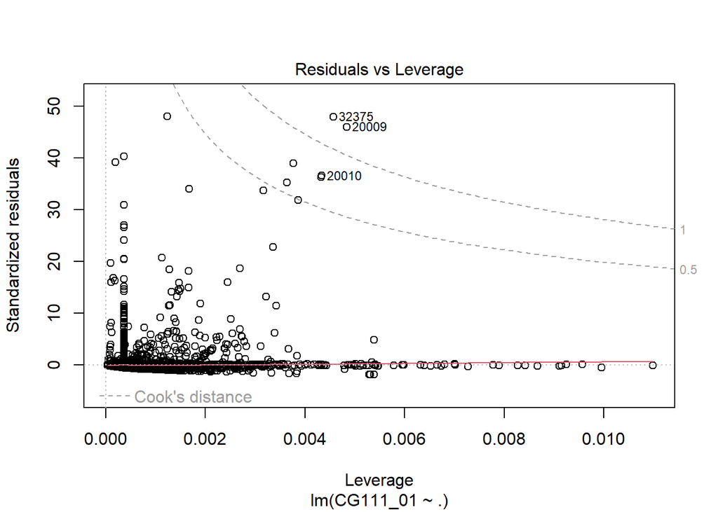

```r
plot(modelo_CB)
```

```r
comparacion <- data.frame(predict.lm(object = modelo_CB, newdata = testing))

comparacion <- data.frame(comparacion, testing[,1])
```

Modeling for the bovine species without outliers: The modeling procedure is repeated for the bovine species, this time using the clean dataset without outliers (CG111_01_cb_w). Relevant variables are selected for the analysis, and the data is split into training (80%) and testing (20%) subsets.

A multiple linear regression model is fitted on the training set using all selected variables, followed by optimization with the stepAIC method to identify the most significant predictors. The results of the optimized model are reviewed through its summary and diagnostic plots.

Finally, predictions are generated on the test set, and a dataframe is created that compares the predicted values with the actual observed values, allowing evaluation of the model’s performance without the influence of outliers.

```r
CG111_01_cb_w <- CG111_01w_atip %>% dplyr::select(CG111_01,CB112, CB121_01,CB121_08, CB121_02,CB121_03, CB121_04,CB121_06 )



split <- sample.split(Y = CG111_01_cb_w$CG111_01, SplitRatio = .80)

training <- subset(x = CG111_01_cb_w, split == T)
testing <- subset(x = CG111_01_cb_w, split == F)

testingok <- testing[,-1]

modelo_CB <- lm(formula = CG111_01 ~., data = training)

summary(modelo_CB)
```

```
##
## Call:
## lm(formula = CG111_01 ~ ., data = training)
##
## Residuals:
##    Min     1Q Median     3Q    Max
## -86528 -22857 -10896  13215 184931
##
## Coefficients:
##             Estimate Std. Error t value Pr(>|t|)
## (Intercept)     68.7      856.5   0.080   0.9361
## CB112         7479.7      424.9  17.602  < 2e-16 ***
## CB121_01     -1909.8      927.4  -2.059   0.0395 *
## CB121_08       490.7      241.7   2.030   0.0424 *
## CB121_02      1249.5      169.2   7.384 1.58e-13 ***
## CB121_03      1782.3      245.7   7.255 4.11e-13 ***
## CB121_04      8271.6      363.6  22.750  < 2e-16 ***
## CB121_06      -651.8      274.8  -2.372   0.0177 *
## ---
## Signif. codes:  0 '***' 0.001 '**' 0.01 '*' 0.05 '.' 0.1 ' ' 1
##
## Residual standard error: 35780 on 30689 degrees of freedom
## Multiple R-squared:  0.1442, Adjusted R-squared:  0.144
## F-statistic: 738.5 on 7 and 30689 DF,  p-value: < 2.2e-16
```

```r
MASS::stepAIC(object = modelo_CB, direction = "both")
```

```
## Start:  AIC=643733.8
## CG111_01 ~ CB112 + CB121_01 + CB121_08 + CB121_02 + CB121_03 +
##     CB121_04 + CB121_06
##
##            Df  Sum of Sq        RSS    AIC
## <none>                   3.9289e+13 643734
## - CB121_08  1 5.2748e+09 3.9295e+13 643736
## - CB121_01  1 5.4295e+09 3.9295e+13 643736
## - CB121_06  1 7.2022e+09 3.9297e+13 643737
## - CB121_03  1 6.7385e+10 3.9357e+13 643784
## - CB121_02  1 6.9802e+10 3.9359e+13 643786
## - CB112     1 3.9667e+11 3.9686e+13 644040
## - CB121_04  1 6.6261e+11 3.9952e+13 644245
```

```
##
## Call:
## lm(formula = CG111_01 ~ CB112 + CB121_01 + CB121_08 + CB121_02 +
##     CB121_03 + CB121_04 + CB121_06, data = training)
##
## Coefficients:
## (Intercept)        CB112     CB121_01     CB121_08     CB121_02     CB121_03
##        68.7       7479.7      -1909.8        490.7       1249.5       1782.3
##    CB121_04     CB121_06
##      8271.6       -651.8
```

```r
summary(modelo_CB)
```

```
##
## Call:
## lm(formula = CG111_01 ~ ., data = training)
##
## Residuals:
##    Min     1Q Median     3Q    Max
## -86528 -22857 -10896  13215 184931
##
## Coefficients:
##             Estimate Std. Error t value Pr(>|t|)
## (Intercept)     68.7      856.5   0.080   0.9361
## CB112         7479.7      424.9  17.602  < 2e-16 ***
## CB121_01     -1909.8      927.4  -2.059   0.0395 *
## CB121_08       490.7      241.7   2.030   0.0424 *
## CB121_02      1249.5      169.2   7.384 1.58e-13 ***
## CB121_03      1782.3      245.7   7.255 4.11e-13 ***
## CB121_04      8271.6      363.6  22.750  < 2e-16 ***
## CB121_06      -651.8      274.8  -2.372   0.0177 *
## ---
## Signif. codes:  0 '***' 0.001 '**' 0.01 '*' 0.05 '.' 0.1 ' ' 1
##
## Residual standard error: 35780 on 30689 degrees of freedom
## Multiple R-squared:  0.1442, Adjusted R-squared:  0.144
## F-statistic: 738.5 on 7 and 30689 DF,  p-value: < 2.2e-16
```

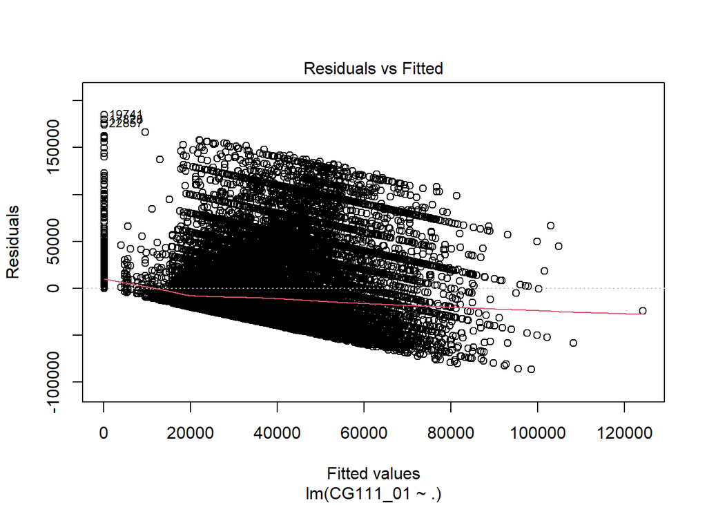

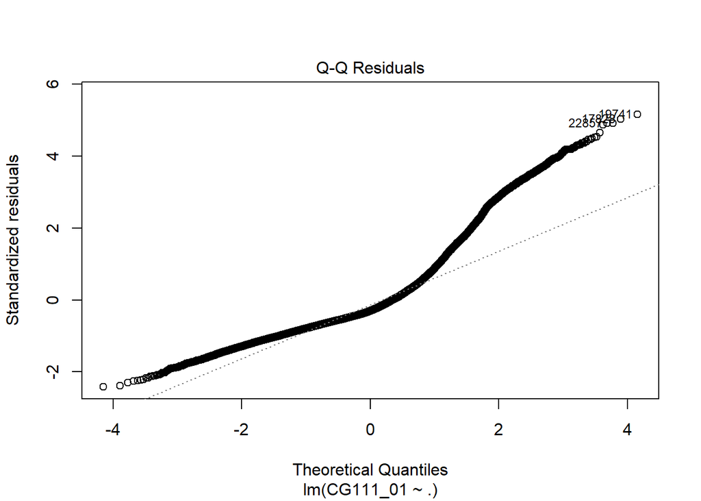

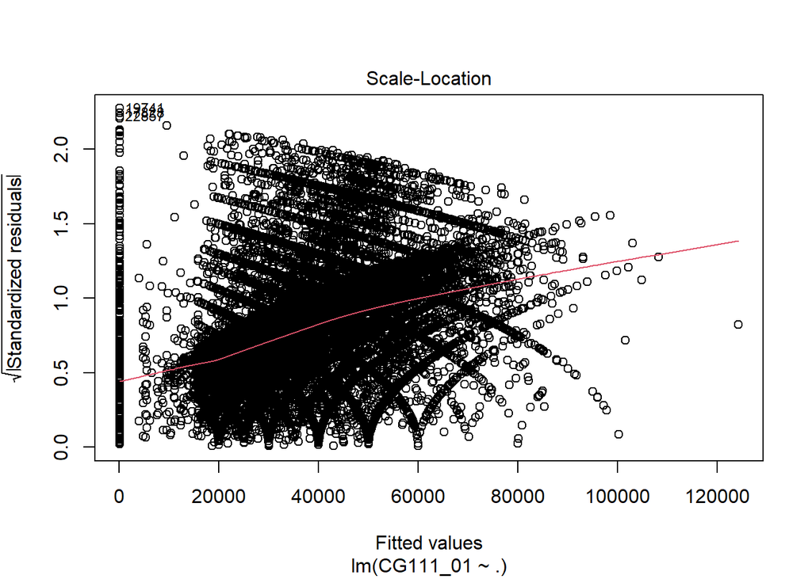

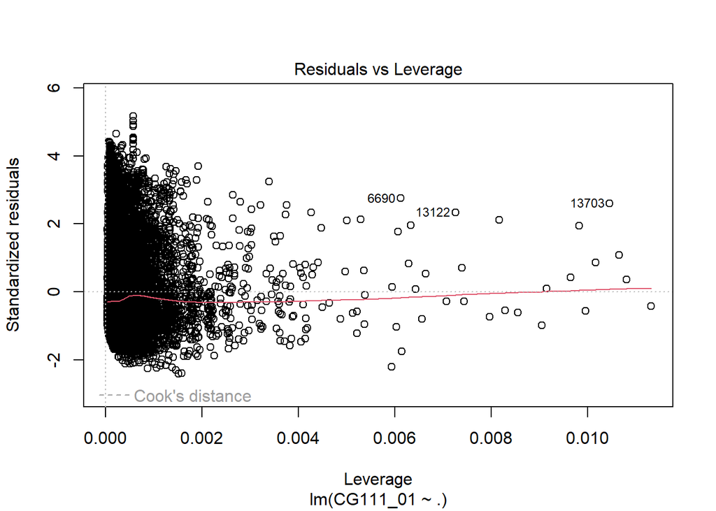

```r
plot(modelo_CB)
```

```r
comparacion <- data.frame(predict.lm(object = modelo_CB, newdata = testing))

comparacion <- data.frame(comparacion, testing[,1])
```

### Methodological decision: species-specific disaggregation

This finding suggests that the behavior of the data could be significantly influenced by the livestock species. Therefore, the methodological decision is made to continue generating models disaggregated by species, while expanding the variables specific to each one. This strategy will allow better capture of the particular dynamics of each group and potentially improve the predictive performance of the models.